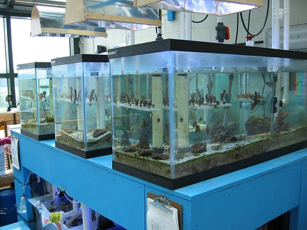

A team of marine biologists was interested in how ocean acidification due to increased atmospheric CO2 was affecting the growth of corals. For three months, they grew coral fragments in each of two treatments: 1) a control treatment at ambient pH, and 2) a treatment at lowered pH. Each coral fragment was held in a separate tank with an independent water supply. They recorded the size of each fragment at the beginning and end of the experiment, and obtained the following data set:

Treatment Initial size (cm) Size at 3 months (cm) Ambient pH 6.5 12.3 Ambient pH 7.5 13.1 Ambient pH 8.3 10.8 Ambient pH 6.9 9.8 Ambient pH 7.1 12.6 Low pH 6.6 6.4 Low pH 6.1 6.3 Low pH 8.0 7.8 Low pH 7.8 7.9 Low pH 7.4 7.3

```r
corals = read.csv(file = "Corals.csv", header = T)
```

Firstly, visualise the differences in growth between the two treatments

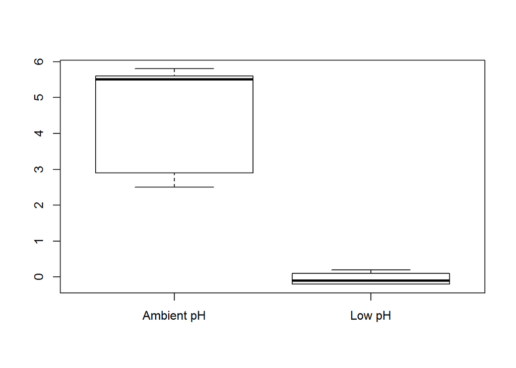

```r
boxplot(Growth~Treatment, data = corals)
```

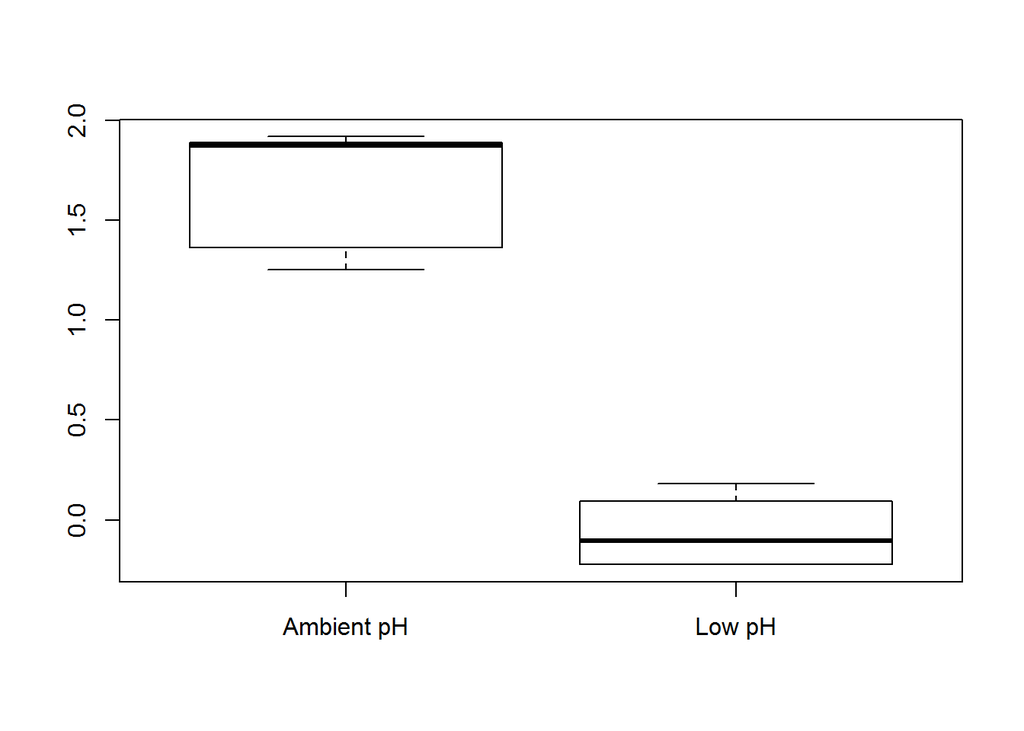

```r
boxplot(log(Growth+1)~Treatment, data = corals)
```

**A)** What statistical test could you use to detect whether lowered pH affects the growth of coral?

```r
# {1:MULTICHOICE:=Two sample t test~Contingency table~Goodness of fit test~Paired t test}
```

**B)** After checking the assumptions of your test, conduct the test, and give the value of the test statistic and P value.

```r
t.test(log(Growth+1)~Treatment, data = corals) # correct analysis
```

```
##
##  Welch Two Sample t-test
##
## data:  log(Growth + 1) by Treatment
## t = 10.28, df = 6.383, p-value = 3.324e-05
## alternative hypothesis: true difference in means is not equal to 0
## 95 percent confidence interval:
##  1.311 2.115
## sample estimates:
## mean in group Ambient pH     mean in group Low pH
##                   1.6579                  -0.0548
```

```r
t.test(Growth~Treatment, data = corals) # incorrect analysis that violates homogeneity of variance assumption
```

```
##
##  Welch Two Sample t-test
##
## data:  Growth by Treatment
## t = 6.186, df = 4.101, p-value = 0.003195
## alternative hypothesis: true difference in means is not equal to 0
## 95 percent confidence interval:
##  2.5 6.5
## sample estimates:
## mean in group Ambient pH     mean in group Low pH
##                     4.46                    -0.04
```

```r
t.test(Size.3months~Treatment, data = corals)# incorrect analysis of size, not growth
```

```
##
##  Welch Two Sample t-test
##
## data:  Size.3months by Treatment
## t = 6.529, df = 6.224, p-value = 0.0005306
## alternative hypothesis: true difference in means is not equal to 0
## 95 percent confidence interval:
##  2.879 6.281
## sample estimates:
## mean in group Ambient pH     mean in group Low pH
##                    11.72                     7.14
```

**C)** Did the corals grow at lowered pH? Support your answer with the results of a statistical test that would effectively test this hypothesis

```r
lowpH = subset(corals, Treatment =="Low pH")
t.test(lowpH$Growth, alternative = "two.sided", mu = 0)
```

```
##
##  One Sample t-test
##
## data:  lowpH$Growth
## t = -0.4924, df = 4, p-value = 0.6483
## alternative hypothesis: true mean is not equal to 0
## 95 percent confidence interval:
##  -0.2656  0.1856
## sample estimates:
## mean of x
##     -0.04
```